# Practical Machine Learning Project

Ricardo Fernandez

December 26th 2015

# Summary

The aim of this report is to predict the manner in which an athlete performed an exercise. This is the `classe` variable find in the training set.

The data for the project can be found at [Group Ware](http://groupware.les.inf.puc-rio.br/har):

- [Training Set](http://d396qusza40orc.cloudfront.net/predmachlearn/pml-training.csv)
- [Test Set](http://d396qusza40orc.cloudfront.net/predmachlearn/pml-testing.csv)

# Data Processing

During the project will be need to work with `caret` and `corrplot` libraries, ensure that you have them already installed.

```r
library(caret)
library(corrplot)
```

Moreover in order to be able to reproduce all the process and obtain the same results here presents will be necessary to set the default seed:

```r
set.seed(12345)
```

## Loading Data

The code blow check for the training and testing datasets, in case they do not exist in the current working directory the date is downloaded and loaded. Otherwise is just loaded.

```r
if (!file.exists("pml-training.csv")) {
  download.file("http://d396qusza40orc.cloudfront.net/predmachlearn/pml-training.csv")
}
if (!file.exists("pml-testing.csv")) {
  download.file("http://d396qusza40orc.cloudfront.net/predmachlearn/pml-testing.csv")
}

trainingSet <- read.csv("pml-training.csv", header=TRUE, na.strings=c("", "NA", "NULL"))
testingSet<- read.csv("pml-testing.csv", header=TRUE, na.strings=c("", "NA", "NULL"))
```

## Cleaning Data

Before do any cleaning it is necessary to check the data structure in order to take the proper decisions.

First we check the size of both sets, and the structure of the training set.

```r
dim(trainingSet)
```

```
## [1] 19622   160
```

```r
dim(testingSet)
```

```
## [1]  20 160
```

As we can see above both sets contain 160 variables, 19622 observations for the training set and 20 observations for the test set.

```r
str(trainingSet)
```

From the output of the `str()` (not shown above because of the amount of data) we observe that there are several columns with quite a lot NAs values which do not add information to the training set.

Since not the complete column contains NA values we define a threshold, in our case we defined `0.95`, so all columns with less than 95% of the values informed will be deleted.

```r
threshold = 0.95
trainingNoNA <- trainingSet[, (nrow(trainingSet)-colSums(is.na(trainingSet)))/nrow(trainingSet) > threshold]

dim(trainingNoNA)
```

```
## [1] 19622    60
```

We reduce the training set from 160 variables to 60 by deleting all the variables with these than 95% of the variables informed.

Since the dataset is not time dependent all the time-series values are useless and can be removed also.

```r
trainingClean <- trainingNoNA[,-c(1:7)]
dim(trainingClean)
```

```
## [1] 19622    53
```

Finally the dataset has been reduced to 53 variables.

# Modeling

Following we proceed to split our `trainingClean` data in two sets:

- Cross-Validation set 30% of the data.
- Training set 70% of the data.

```r
triningPartition <- createDataPartition(trainingClean$classe, p = 0.7, list=FALSE)
trainSubSet <- trainingClean[triningPartition,]
crossValSubSet <- trainingClean[-triningPartition,]
```

The aim of this split is to obtain the model by using the `trainSubSet` and validate it accuracy in the `crossValSubSet`.

### Correlation Study

For the model prediction we can exclude those highly correlated variables so they do not significant advantage to the prediction model. Following we can observe how the set correlates

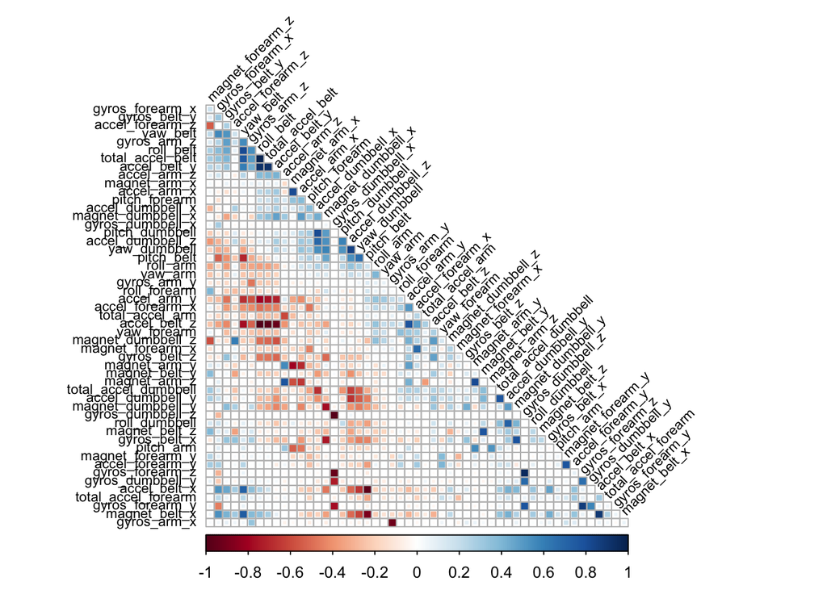

```r
corMat <- cor(trainSubSet[,-dim(trainSubSet)[2]])
corrplot(corMat, method = "square", type="lower", order="AOE", tl.cex = 0.7,
         tl.col="black", tl.srt = 45, diag = FALSE)
```

As we see above there are some variables that correlates, we will exclude those correlated variables with a correlation value higher than 0.8.

```r
highlyCor <- findCorrelation(corMat, cutoff = 0.8)
trainNotCorr <- trainSubSet[,-highlyCor]
```

We will exclude the following variables:

```
##  [1] "accel_belt_z"     "roll_belt"        "accel_belt_y"
##  [4] "accel_dumbbell_z" "accel_belt_x"     "pitch_belt"
##  [7] "accel_arm_x"      "accel_dumbbell_x" "magnet_arm_y"
## [10] "gyros_forearm_y"  "gyros_dumbbell_x" "gyros_dumbbell_z"
## [13] "gyros_arm_x"
```

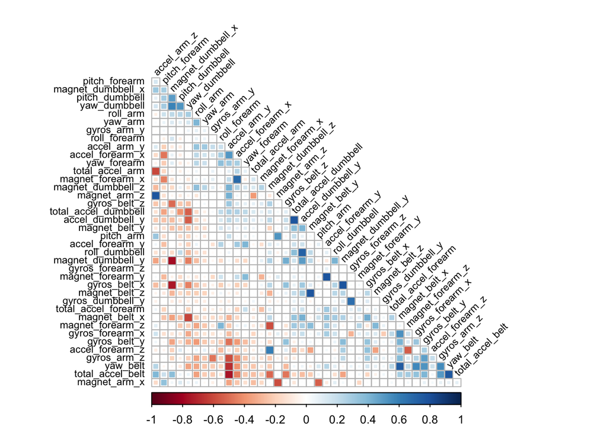

```r
cormat <- cor(trainNotCorr[,-dim(trainNotCorr)[2]])
corrplot(cormat, method = "square", type="lower", order="AOE", tl.cex = 0.7,
         tl.col="black", tl.srt = 45, diag = FALSE)
```

### Random Forest Model

In order to reduce the overfitting and conserve the variance we choose to apply Random Forest training for obtain our model.

```r
model <- train(classe~.,
                    method = "rf",
                    data=trainNotCorr,
                    trControl = trainControl(method = "cv"), importance=TRUE)
```

#### Predictors

By using the `varImpPlot` to the `model$finalModel` as follow below we can observe the importance of the predictors from the model:

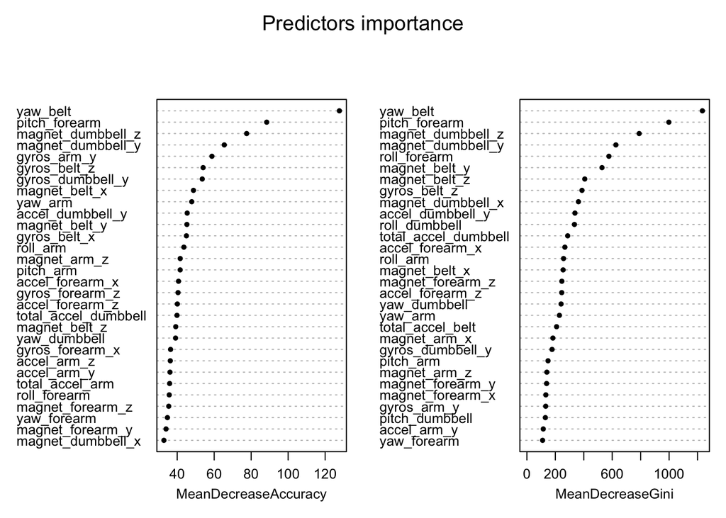

```r
varImpPlot(model$finalModel, main = "Predictors importance", pch = 20, cex = 0.8)
```

#### Predict Outcomes Using Validation Set

Finally and before apply our model to the `testingSet` we can validate it with the `crossValSubSet`.

```r
prediction <- predict(model, crossValSubSet)
```

```r
confMatrix <- confusionMatrix(crossValSubSet$classe, prediction)

sum(diag(confMatrix$table))/sum(confMatrix$table)
```

```
## [1] 0.9884452
```

```r
confMatrix$overall[1]
```

```
##  Accuracy
## 0.9884452
```

# Testing Set

Finally the prediction for the 20 cases from the Testing Data Set:

```r
predict(model, testingSet)
```

```
##  [1] B A B A A E D B A A B C B A E E A B B B
## Levels: A B C D E
```